# The inkscaper package: R wrapper for Inkscape

2023-09-13

The inkscaper package provide a modern and simple toolkit for Scalable Vector Graphics (SVG) processing in R. It wraps the [Inkscape](https://inkscape.org/) which is a Free and open source vector graphics editor for GNU/Linux, Windows and macOS.

It offers a rich set of features and is widely used for both artistic and technical illustrations such as cartoons, clip art, logos, typography, diagramming and flowcharting. It uses vector graphics to allow for sharp printouts and renderings at unlimited resolution and is not bound to a fixed number of pixels like raster graphics. Inkscape uses the standardized SVG file format as its main format, which is supported by many other applications including web browsers.

## Installing `inkscape`

To install Inkscape on your platform follow the instruction available at: https://inkscape.org/

Note: during Windows installation allow “set path”

## Installing `inkscaper` R package

```r
library(devtools)
install_github("JacekPardyak/inkscaper")
```

[output not shown]

```
## Installing 10 packages: dplyr, askpass, knitr, rematch, labeling, credentials, wk, units, classInt, DT
```

[output not shown]

```
## installing the source packages 'knitr', 'units'
```

[output not shown]

## Using Inkscape Actions

While obviously Inkscape is primarily intended as a GUI application, it can be used for doing SVG processing on the command line as well. [Inkscape Actions](https://inkscape.org/doc/inkscape-man.html) available in versions Inkscape 1.3 (0e150ed6c4, 2023-07-21) are listed below.

|  | Action | Description |
| --- | --- | --- |
| 1 | about | Inkscape version, authors, license |
| 2 | action-list | Print a list of actions and exit |
| 3 | clone | Create a clone (a copy linked to the original) of selected object |
| 4 | clone-link | Relink the selected clones to the object currently on the clipboard |
| 5 | clone-link-lpe | Creates a new path, applies the Clone original LPE, and refers it to the selected path |
| 6 | clone-unlink | Cut the selected clones' links to the originals, turning them into standalone objects |
| 7 | clone-unlink-recursively | Unlink all clones in the selection, even if they are in groups. |
| 8 | com.inkscape.generate.generate-voronoi | Voronoi Pattern |
| 9 | com.inkscape.generate.generate-voronoi.noprefs | Voronoi Pattern |
| 10 | com.kaioa.lorem-ipsum | Lorem ipsum |

[output cut: 1057 more lines]

### Function `inx_actions()`

```r
library(inkscaper)
output = "https://dev.w3.org/SVG/tools/svgweb/samples/svg-files/cartman.svg" %>%
  inx_actions(actions = NA, ext = ".png")
```

## Using Inkscape Extensions

[Inkscape Extensions](https://inkscape.org/gallery/=extension/) are small programs that extend Inkscape’s functionality. They can provide features for specific tasks, experimentation, or art styles. They can also add support for special hardware or different export formats. While many extensions are included with Inkscape, you can also install extensions written by third parties or write your own. The table below shows the list of extensions available in Inkscape of version Inkscape 1.3 (0e150ed6c4, 2023-07-21) with descriptions.

|  | Extension | Description |
| --- | --- | --- |
| 1 | addnodes.py | usage: addnodes.py [-h] [--output OUTPUT] [--segments SEGMENTS] [--max MAX] [--method METHOD] [--unit UNIT] [--id IDS] [--selected-nodes SELECTED_NODES] [INPUT_FILE] Extension to split a path by addin… |
| 2 | color_blackandwhite.py | usage: color_blackandwhite.py [-h] [--output OUTPUT] [-t THRESHOLD] [--id IDS] [--selected-nodes SELECTED_NODES] [INPUT_FILE] Convert colours to black and white positional arguments: INPUT_FILE Filena… |
| 3 | color_brighter.py | usage: color_brighter.py [-h] [--output OUTPUT] [--id IDS] [--selected-nodes SELECTED_NODES] [INPUT_FILE] Make colours brighter positional arguments: INPUT_FILE Filename of the input file (default is … |
| 4 | color_custom.py | usage: color_custom.py [-h] [--output OUTPUT] [--tab TAB] [-r R] [-g G] [-b B] [-s SCALE] [--id IDS] [--selected-nodes SELECTED_NODES] [INPUT_FILE] Custom colour functions per channel positional argum… |
| 5 | color_darker.py | usage: color_darker.py [-h] [--output OUTPUT] [--id IDS] [--selected-nodes SELECTED_NODES] [INPUT_FILE] Make the colours darker positional arguments: INPUT_FILE Filename of the input file (default is … |
| 6 | color_desaturate.py | usage: color_desaturate.py [-h] [--output OUTPUT] [--id IDS] [--selected-nodes SELECTED_NODES] [INPUT_FILE] Remove color but maintain intesity positional arguments: INPUT_FILE Filename of the input fi… |
| 7 | color_grayscale.py | usage: color_grayscale.py [-h] [--output OUTPUT] [--id IDS] [--selected-nodes SELECTED_NODES] [INPUT_FILE] Make all colours grayscale positional arguments: INPUT_FILE Filename of the input file (defau… |
| 8 | color_hsl_adjust.py | usage: color_hsl_adjust.py [-h] [--output OUTPUT] [--tab TAB] [-x HUE] [-s SATURATION] [-l LIGHTNESS] [--random_h RANDOM_HUE] [--random_s RANDOM_SATURATION] [--random_l RANDOM_LIGHTNESS] [--id IDS] [-… |
| 9 | color_lesshue.py | usage: color_lesshue.py [-h] [--output OUTPUT] [--id IDS] [--selected-nodes SELECTED_NODES] [INPUT_FILE] Remove Hue from the color positional arguments: INPUT_FILE Filename of the input file (default … |
| 10 | color_lesslight.py | usage: color_lesslight.py [-h] [--output OUTPUT] [--id IDS] [--selected-nodes SELECTED_NODES] [INPUT_FILE] Reduce the light of the color positional arguments: INPUT_FILE Filename of the input file (de… |

[output cut: 150 more lines]

### Function `inx_extension()`

In this example we download `SVG`, convert it to `DXF` and read with `sf` package. Simple features (`LINESTRING`) are plotted with `ggplot2`.

```r
library(tidyverse)
library(sf)
```

[figure not shown]

```r
"https://upload.wikimedia.org/wikipedia/commons/3/30/Den_Haag_wapen.svg" %>%
  inx_extension(inkscape_extension_name = "dxf12_outlines.py", ext = ".dxf") %>%
  st_read() %>%
  ggplot() +
  geom_sf()
```

[figure not shown]

```r
"https://upload.wikimedia.org/wikipedia/commons/3/30/Den_Haag_wapen.svg" %>%
  inx_svg2sf() %>%
  ggplot() +
  geom_sf()
```

## More examples

### W3C logo

In the first example we convert a `SVG` to `DXF` and plot `SF`. In the other we flip object in Inkscape before conversion.

```r
output = "https://dev.w3.org/SVG/tools/svgweb/samples/svg-files/w3c.svg" %>%
  inx_actions(actions = NA, ext = ".png")
```

[figure not shown]

```r
"https://dev.w3.org/SVG/tools/svgweb/samples/svg-files/w3c.svg" %>%
  inx_svg2sf() %>%
  ggplot() +
  geom_sf()
```

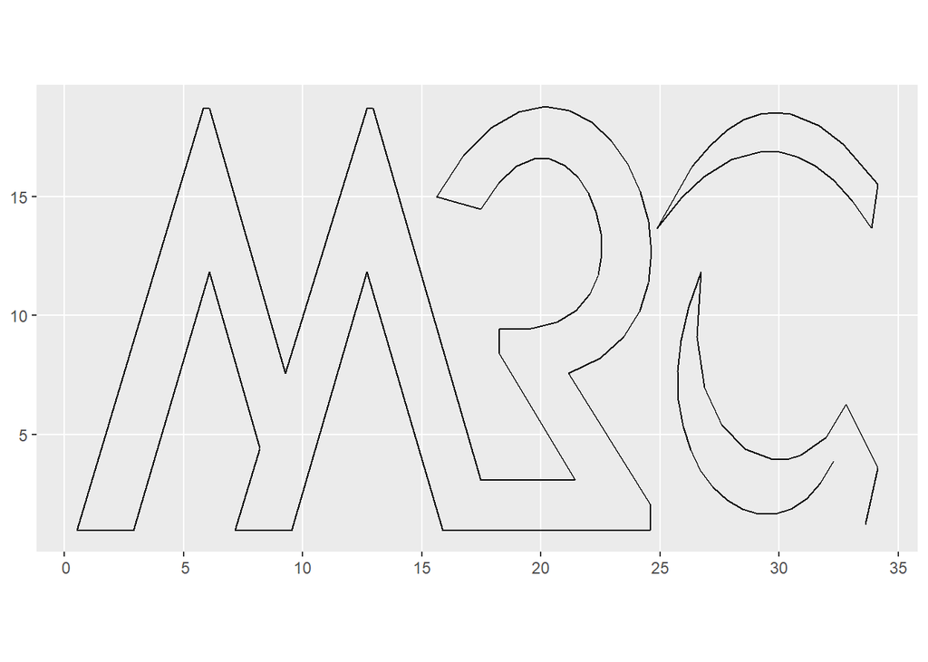

```r
"https://dev.w3.org/SVG/tools/svgweb/samples/svg-files/w3c.svg" %>%
  inx_actions(actions = "select-all;object-flip-vertical", ext = ".svg") %>%
  inx_svg2sf %>%
  ggplot() +
  geom_sf()
```

### Italian flag

```r
output <- "https://dev.w3.org/SVG/tools/svgweb/samples/svg-files/italian-flag.svg" %>%
  inx_actions(actions = NA, ext = ".png")
```

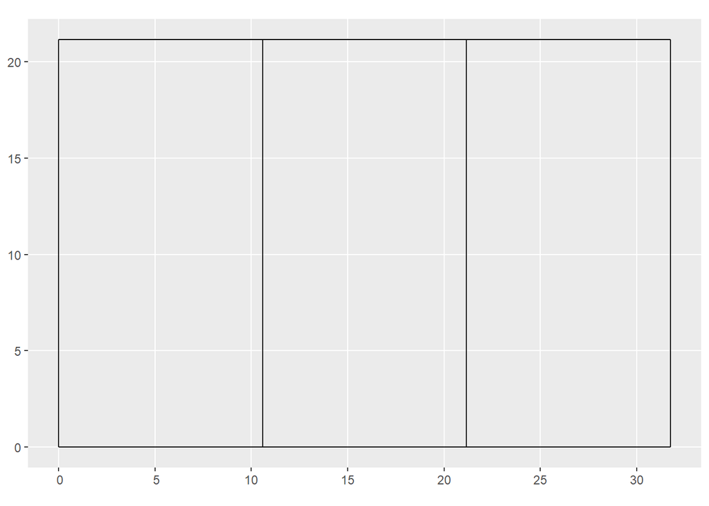

```r
"https://dev.w3.org/SVG/tools/svgweb/samples/svg-files/italian-flag.svg" %>%
  inx_svg2sf() %>%
  ggplot() +
  geom_sf()
```

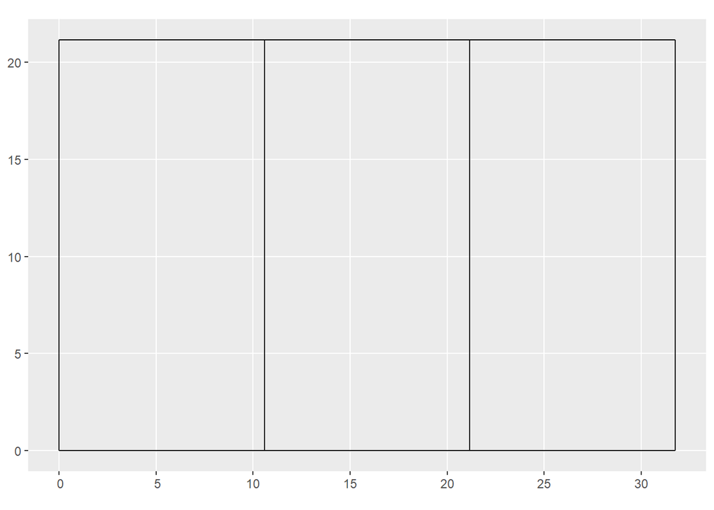

```r
"https://dev.w3.org/SVG/tools/svgweb/samples/svg-files/italian-flag.svg" %>%
inx_actions(actions = "select-all;object-to-path", ext = ".svg") %>%
  inx_svg2sf() %>%
  ggplot() +
  geom_sf()
```

### Heart

In this example we define `SF` linestrings from points given by a formula for [Heart Curve](https://mathworld.wolfram.com/HeartCurve.html) and convert it into `SVG` path.

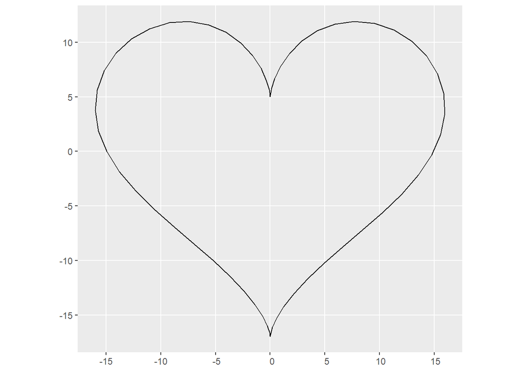

```r
heart <- tibble(t = seq(0, 2*pi, 0.1)) %>%
  mutate( x = 16*sin(t)^3 ) %>%
  mutate( y = 13*cos(t)-5*cos(2*t)-2*cos(3*t)-cos(4*t))

heart <- heart %>% bind_rows(heart %>% slice(1)) %>% select(x, y) %>% as.matrix() %>%
  st_linestring() %>% st_sfc() %>% st_sf()
heart %>% ggplot() +
  geom_sf()
```

```r
output = heart %>% inx_sf2svg()
```

```
## writing: substituting ENGCRS["Undefined Cartesian SRS with unknown unit"] for missing CRS
```

```
## Writing layer `inx_30cc31b54779' to data source
##   `C:\Users\jacek\AppData\Local\Temp\Rtmp8sDamw\inx_30cc31b54779.dxf' using driver `DXF'
## Writing 1 features with 0 fields and geometry type Line String.
```

This is `SVG` generated with this procedure:

[figure not shown]

The source `XML` looks like this:

```r
output %>%
  xml2::read_xml()
```

```
## {xml_document}
## <svg viewBox="0 0 121.85992 109.79527" width="121.85992" height="109.79527" version="1.1" id="svg5" docname="inx_30cc473fa" xmlns:inkscape="http://www.inkscape.org/namespaces/inkscape" xmlns:sodipodi="http://sodipodi.sourceforge.net/DTD/sodipodi-0.dtd" xmlns="http://www.w3.org/2000/svg" xmlns:svg…
## [1] <sodipodi:namedview id="namedview5" pagecolor="#ffffff" bordercolor="#000 ...
## [2] <desc id="desc1">inx_30cc60cddf4 - scale = 1.000000, origin = (0.000000,  ...
## [3] <defs id="defs4">\n  <marker id="DistanceX" orient="auto" refX="0" refY=" ...
## [4] <g inkscape:groupmode="layer" inkscape:label="0" id="g5" transform="trans ...
```

As a reference check heart from https://dev.w3.org/SVG/tools/svgweb/samples/svg-files/heart.svg

[figure not shown]

. This example resembles two Inkscape extensions:

- `funcplot.py`
- `param_curves.py`

Both are found under Extensions -> Render in the Inkscape GUI.

```r
filename <- system.file("shape/nc.shp", package="sf")
nc <- st_read(filename)
```

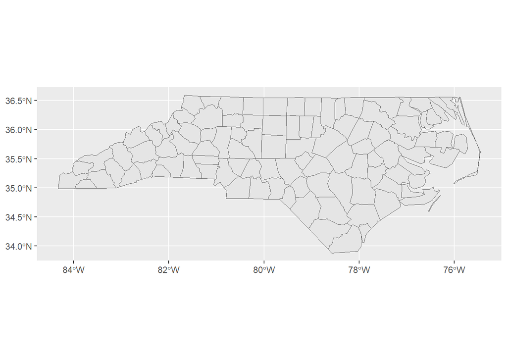

```r
nc %>% ggplot() +
  geom_sf()
```

```r
output = nc %>% inx_sf2svg()
```

```
## Writing layer `inx_30cc2dc07ced' to data source
##   `C:\Users\jacek\AppData\Local\Temp\Rtmp8sDamw\inx_30cc2dc07ced.dxf' using driver `DXF'
## Writing 100 features with 0 fields and geometry type Multi Polygon.
```

This is `SVG` generated with this procedure:

[figure not shown]

### Actions on Simple Features

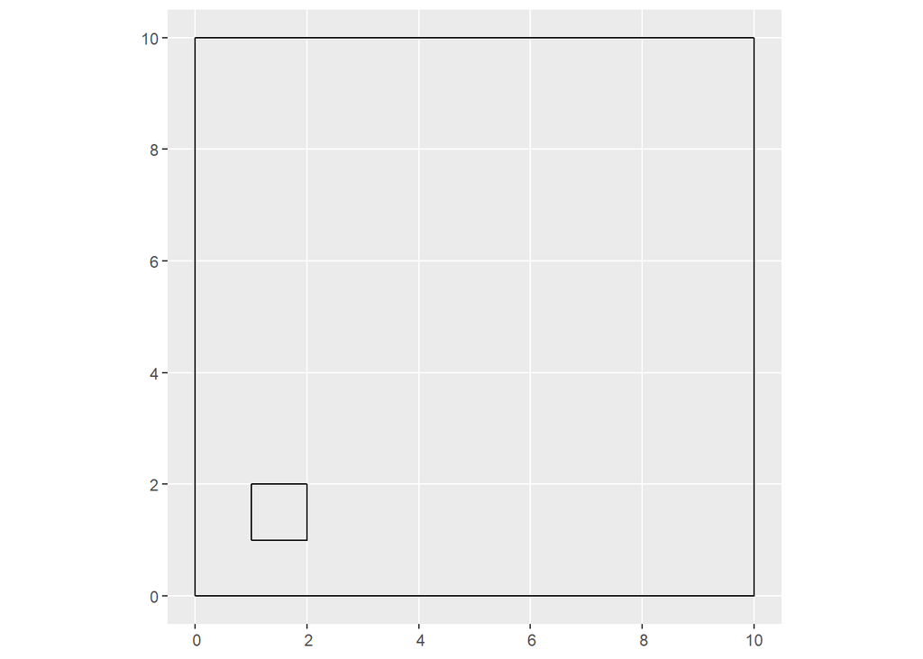

```r
sf_1 = matrix(c(0,0,10,0,10,10,0,10,0,0),ncol=2, byrow=TRUE)  %>%
  list() %>% st_multilinestring() %>% st_sfc() %>% st_sf()
sf_2 = matrix(c(1,1,1,2,2,2,2,1,1,1),ncol=2, byrow=TRUE) %>%
  list() %>% st_multilinestring() %>% st_sfc() %>% st_sf()
collection <- sf_1 %>% bind_rows(sf_2)
collection %>% ggplot() +
  geom_sf()
```

```r
inx_svg = collection %>% inx_sf2svg()
```

```
## writing: substituting ENGCRS["Undefined Cartesian SRS with unknown unit"] for missing CRS
```

```
## Writing layer `inx_30cc26ef4cd8' to data source
##   `C:\Users\jacek\AppData\Local\Temp\Rtmp8sDamw\inx_30cc26ef4cd8.dxf' using driver `DXF'
## Writing 2 features with 0 fields and geometry type Multi Line String.
```

```r
inx_svg  %>% xml2::read_xml()
```

```
## {xml_document}
## <svg viewBox="0 0 38.795276 38.795278" width="38.795277" height="38.795277" version="1.1" id="svg6" docname="inx_30cc545e6d55" xmlns:inkscape="http://www.inkscape.org/namespaces/inkscape" xmlns:sodipodi="http://sodipodi.sourceforge.net/DTD/sodipodi-0.dtd" xmlns="http://www.w3.org/2000/svg" xmlns:…
## [1] <sodipodi:namedview id="namedview6" pagecolor="#ffffff" bordercolor="#000 ...
## [2] <desc id="desc1">inx_30cc1c411072 - scale = 1.000000, origin = (0.000000, ...
## [3] <defs id="defs4">\n  <marker id="DistanceX" orient="auto" refX="0" refY=" ...
## [4] <g inkscape:groupmode="layer" inkscape:label="0" id="g6" transform="trans ...
```

[figure not shown]

```r
collection_top <- inx_svg %>%
  inx_actions(actions =  "select-by-id:path20,path18;object-align:left | top", ext = ".svg")
```

[figure not shown]

```r
collection_bottom <- inx_svg %>%
  inx_actions(actions = "select-by-id:path20,path18;object-align:right | bottom", ext = ".svg")
```

[figure not shown]

### R Logo

```r
logo = system.file("extdata", "R_logo.svg", package = "inkscaper") %>%
  inx_svg2sf() %>%
  select(geometry)
```

[figure not shown]

```r
# POLYGON: ellipse
ellipse <- logo %>% slice(1:128) %>%
  select(geometry) %>% st_union() %>% st_polygonize() %>%
  first() %>%
  first() %>% st_sfc()  %>% st_sf(geometry = .)
hole <- logo %>% slice(129:215) %>%
  select(geometry) %>% st_union() %>% st_polygonize() %>%
  first() %>%
  first() %>% st_sfc()  %>% st_sf(geometry = .)
ellipse <- ellipse %>% st_difference(hole) %>% mutate(colour = "#b8b8bdff")

# POLYGON: R letter
rletter <- logo %>% slice(216:276) %>%
  select(geometry) %>% st_union() %>% st_polygonize() %>%
  first() %>%
  first() %>% st_sfc() %>% st_sf(geometry = .)
hole <- logo %>% slice(277:301)  %>%
  select(geometry) %>% st_union() %>% st_polygonize() %>%
  first() %>%
  first() %>% st_sfc()  %>% st_sf(geometry = .)
rletter <- rletter %>% st_difference(hole) %>% mutate(colour = "#1c61b3ff")

ggplot() +
  geom_sf(data = ellipse, aes(fill = colour)) +
  geom_sf(data = rletter, aes(fill = colour)) +
  scale_fill_identity()
```

### Inkscape Logo

```r
output = system.file("extdata", "Inkscape_logo.svg", package = "inkscaper") %>%
  inx_svg2sf() %>%
  select(geometry) %>% st_union() %>% st_polygonize() %>% first()
```

[figure not shown]

```r
output = (output %>% nth(1)) %>%
  st_union(output %>% nth(2)) %>%
  st_union(output %>% nth(3)) %>%
  st_union(output %>% nth(4))
output %>%
  ggplot() +
  aes(fill = "black") +
  geom_sf() +
  scale_fill_identity()
```

## Non-GUI environments

Some known limitations:

- in a non-GUI environment such as [Colab](https://colab.research.google.com/), some actions will not work because they require a GUI to run, although the `inkscaper` package only requires the CLI to run commands.